# Introduction to R, Rstudio and setup

lession 1

Eviatar Guttman

Last updated: 09-05-2021

# preperations

נא וודאו שתוכנת R, ותוכנת Rstudio מותקנות. לאחר התקנת התוכנות יש לפתוח את תוכנת ה- Rstudio ולעתיק את הטקסט הבא לחלון ה Console, ולהקיש Enter:

`install.packages("tidyverse")`

זה יתקין קבוצת חבילות שנשתמש בהן. (וודאו שאתם מחוברים לאינטרנט)

לאחר ההתקנה אפשר לקרוא לחבילות עם הפקודה library

```r
library(tidyverse)
```

**הגדרות מערכת**  
תחת תפריט tools, בחרו ב global options וודאו לכבות את restore על המאפיינים כפי שבתמונה:

[figure not shown]

בלשונית ה code -> saving, בחרו קידוד טקסט UTF-8. זה יבטיח שהעברית תוצג כהלכה ולא בג’יבריש.

[figure not shown]

בדקו שבהקלדת הפקודה Sys.getlocale בקונסולה מתקבל הפלט:

```r
Sys.getlocale()
```

```
## [1] "LC_COLLATE=Hebrew_Israel.1255;LC_CTYPE=Hebrew_Israel.1255;LC_MONETARY=Hebrew_Israel.1255;LC_NUMERIC=C;LC_TIME=Hebrew_Israel.1255"
```

אם תוכנה לא זיהתה שה Local הוא בעברית הקלידו:

`Sys.setlocale("LC_ALL", "hebrew")`

# Basic use of the Console

## introduction

אריתמטיקה , אינסוף, ייצוג של מספרים גדולים, ומספר ביטויים בשורה אחת.

```r
# A note starts with #

# arithmetics
2 + 3 * 3
```

```
## [1] 11
```

```r
# infinity
1 / 0
```

```
## [1] Inf
```

```r
# large numbers
2 ^ 50
```

```
## [1] 1.1259e+15
```

```r
# 2^ 50 = 1.1259 X 10^15

# seperate several expressions with ";"
1 + 1 ; 2 + 1  ; 3 + 1
```

```
## [1] 2
## [1] 3
## [1] 4
```

פונקציות מתמטיות נפוצות:

```r
exp(1)
```

```
## [1] 2.718282
```

```r
log(2.718282)
```

```
## [1] 1
```

```r
sqrt(2)
```

```
## [1] 1.414214
```

```r
abs(-5)
```

```
## [1] 5
```

```r
ceiling(1.2)
```

```
## [1] 2
```

```r
floor(1.6)
```

```
## [1] 1
```

```r
round(1.2)
```

```
## [1] 1
```

```r
# modulus
7 %% 3
```

```
## [1] 1
```

```r
# integer division
7 %/% 3
```

```
## [1] 2
```

יש טעות נומרית:

מספרים נומריים מסוג `double` מיוצגים ב-R בפורמט Double-precision floating-point התופס 64 ביט בזכרון המחשב לצורך ייצוג מספר. שיטת ה-floating-point מציינת את עובדה שבשיטת ייצוג זו, מספר הספרות משמאל לנקודה העשרונית ומימין לה גמיש, ומשתנה בהתאם למספר המיוצג.

```r
sin(2 * pi )
```

[output not shown]

```r
sqrt(2) ^ 2
```

```
## [1] 2
```

```r
sqrt(2) ^ 2 == 2
```

```
## [1] FALSE
```

אם רוצים להשוות בין הערכים:

```r
dplyr::near(sqrt(2)^2, 2)
```

```
## [1] TRUE
```

יש ערך שהוא `NaN` - “לא מספר”:

```r
sqrt(-1)
0 / 0
```

[output not shown]

```r
Inf - Inf
```

```
## [1] NaN
```

```r
Inf - Inf + 3
```

```
## [1] NaN
```

## getting help

כאשר רוצים לברר על פונקציה, מקלידים סימן שאלה לפני שם הפונקציה:

`?exp()`

`?abs()`

מומלץ לחפש ב-google ובפורום R ב-Stackoverflow. ב-R יש מספר דיאלקטים. אנו נתמקד בעיקר בסגנון ה-tidyverse. בחלק גדול מהפוסטים בפורום של Stackoverlflow יש פתרונות במספר דרכים שונות.

[figure not shown]

## logical operations

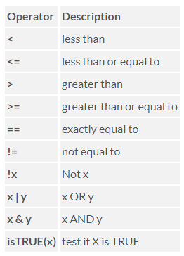

```r
2 < 1
```

```
## [1] FALSE
```

```r
2 <= 2
```

```
## [1] TRUE
```

```r
1 == 1 + 1
```

```
## [1] FALSE
```

```r
2 != 1
```

```
## [1] TRUE
```

```r
(1 == 1 ) & (1 == 2)
```

```
## [1] FALSE
```

```r
(1 == 1 ) | (1 == 2)
```

```
## [1] TRUE
```

# vectors and objects

## introduction

האובייקט הבסיסי ב-R הוא ווקטור. סקלר הוא למעשה ווקטור באורך 1.

A vector is a sequence of data elements of the same basic type. Members of a vector are called Components.

סוגים נפוצים של ווקטורים:

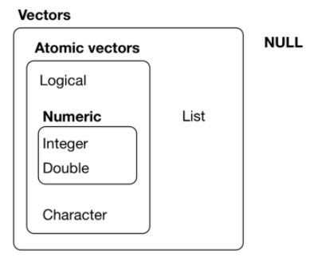

## numeric vectors

```r
1:5
```

```
## [1] 1 2 3 4 5
```

```r
5:1
```

```
## [1] 5 4 3 2 1
```

```r
seq(0, 25, by = 5)
```

```
## [1]  0  5 10 15 20 25
```

```r
rep(1:3, each = 3)
```

```
## [1] 1 1 1 2 2 2 3 3 3
```

```r
1:5 / 100
```

```
## [1] 0.01 0.02 0.03 0.04 0.05
```

```r
c(3, 5, 37)
```

```
## [1]  3  5 37
```

```r
c(1:3, 100:98)
```

```
## [1]   1   2   3 100  99  98
```

```r
numeric(10)
```

```
##  [1] 0 0 0 0 0 0 0 0 0 0
```

```r
# empty vector:
numeric()
## numeric(0)
```

## assign name to object

הסימן לקשר בין אובייקט לבין שם הוא `<-`. אפשר להשתמש בסימן `=`, אך מוטב לא לעשות זאת. אפשר להשתמש בקיצור מקלדת alt + - (אלט מינוס) כדי לקשר בין אובייקט לבין שם.

```r
x <- 1:20/10
```

אם נקרא לאובייקט בשמו, הערכים של האובייקט יודפסו ב-`console`.

```r
x
```

```
##  [1] 0.1 0.2 0.3 0.4 0.5 0.6 0.7 0.8 0.9 1.0 1.1 1.2 1.3 1.4 1.5 1.6 1.7 1.8 1.9
## [20] 2.0
```

```r
x + 30
```

```
##  [1] 30.1 30.2 30.3 30.4 30.5 30.6 30.7 30.8 30.9 31.0 31.1 31.2 31.3 31.4 31.5
## [16] 31.6 31.7 31.8 31.9 32.0
```

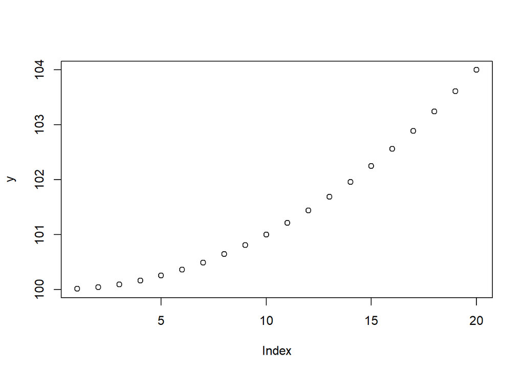

```r
y <-  x^2 + 100

plot(y)
```

```r
class(y)
```

```
## [1] "numeric"
```

```r
typeof(y)
```

```
## [1] "double"
```

```r
length(y)
```

```
## [1] 20
```

## names of variables

שם חייב להתחיל באות בשפה האנגלית.  
בכדי לשלב יותר ממילה אחת בשם אפשר להשתמש באחת משתי האפשרויות:

`my_15_variable_name` `My15VariableName`

בלי שמות בעברית, ללא רווחים, ומומלץ גם לא להשתמש בנקודות. ( לדוגמא: `my.var.name` )

מוטב לא להשתמש במילים שמורות כגון:

`if else` `repeat` `while` `function` `for` `in` `next` `break`  
`TRUE` `FALSE` `NULL` `Inf` `NaN` `NA` `NA_integer_` `NA_real_` `NA_complex_` `NA_character_`

את רשימת המילים השמורות ניתן לראות ב:

`?reserved`

## logical vectors

A logical vector is a vector that only contains TRUE and FALSE (and also NA) values. In R, true values are designated with TRUE, and false values with FALSE. logicals are very usefull for indexing other vectors.

```r
x <- c(TRUE, TRUE , FALSE)

y <- c(TRUE, FALSE, FALSE)

x & y
```

```
## [1]  TRUE FALSE FALSE
```

```r
x | y
```

```
## [1]  TRUE  TRUE FALSE
```

```r
!x
```

```
## [1] FALSE FALSE  TRUE
```

הערך `TRUE` נספר כ-1, הערך `FALSE` נספר כ-0

```r
sum(x)
```

```
## [1] 2
```

```r
mean(x)
```

```
## [1] 0.6666667
```

## NA’s

`NA` זה “לא זמין” Not available. `NA` מייצג ערך לא ידוע (להבדיל מ-`NaN` שמייצג ערך שאינו מספר)

```r
x <- c(1, NA, 3)

x + 3
```

```
## [1]  4 NA  6
```

```r
NA > 5
```

```
## [1] NA
```

```r
NA == NA
```

```
## [1] NA
```

```r
# y is Eviatar's age. We don't know how old is he.
y <- NA

# Let z be Anat's age. We don't know how old she is.
z <- NA

# Are Eviatar and Anat the same age?
y == z
```

```
## [1] NA
```

```r
# We don't know!
```

NA זה ערך מדבק!!  
בפונקציות שעושות סכימה, בד"כ יש ארגומנט שנקרא `na.rm` המאפשר הסרת ערכי `NA` טרם החישוב.

```r
mean(x)
```

```
## [1] NA
```

```r
mean(x, na.rm = TRUE)
```

```
## [1] 2
```

כדי לבדוק האם ישנם ערכים חסרים:

```r
is.na(x)
```

```
## [1] FALSE  TRUE FALSE
```

```r
sum(is.na(x))
```

```
## [1] 1
```

# matrix

מטריצה ב-R זה ווקטור שהוסיפו לו תכונה (`attribute`) של ממד (`dimentions`).

```r
(x <- 1:12)
```

```
##  [1]  1  2  3  4  5  6  7  8  9 10 11 12
```

```r
# A Vector has no abbribues:
attributes(x)
## NULL

# It only has length and type:
length(x)
```

```
## [1] 12
```

```r
typeof(x)
```

```
## [1] "integer"
```

```r
class(x)
```

```
## [1] "integer"
```

```r
# define dimensions to the vector
dim(x) <- c(3,4)

x
```

```
##      [,1] [,2] [,3] [,4]
## [1,]    1    4    7   10
## [2,]    2    5    8   11
## [3,]    3    6    9   12
```

```r
attributes(x)
```

```
## $dim
## [1] 3 4
```

```r
# the class is changed
class(x)
```

```
## [1] "matrix" "array"
```

```r
# the type is still integer
typeof(x)
```

```
## [1] "integer"
```

אפשר ליצור מטריצה עם הפונקציה `matrix`:

```r
(y <- matrix(1:4, nrow = 2))
```

```
##      [,1] [,2]
## [1,]    1    3
## [2,]    2    4
```

```r
matrix(1:4, nrow = 2, byrow = T)
```

```
##      [,1] [,2]
## [1,]    1    2
## [2,]    3    4
```

הוספה או מכפלה בסקלר תחושב לכל ערך:

```r
y + 10
```

```
##      [,1] [,2]
## [1,]   11   13
## [2,]   12   14
```

```r
y * 5
```

```
##      [,1] [,2]
## [1,]    5   15
## [2,]   10   20
```

# data frame

`data frame` זו הדרך הנפוצה ביותר אחסון נתונים ב-R, ועל פי רוב הוא משמש לניתוח נתונים. זו טבלה דו-ממדית. רשימה (`list`) של ווקטורים בעלי אורך זהה (מוצגים באופן אנכי). כל שורה היא תצפית וכל עמודה היא משתנה.

```r
df <- data.frame(id = 1:5,
           var1 = rnorm(5),
           var2 = sample(letters[1:3], 5, replace = T),
           var3 = c("milk", "cheese", "kottage", "yello", "soy"))
df
```

```
##   id       var1 var2    var3
## 1  1 -0.8384450    b    milk
## 2  2 -0.1031400    b  cheese
## 3  3 -0.7306229    b kottage
## 4  4 -1.0824128    a   yello
## 5  5  2.0503083    c     soy
```

הטבלה מורכבת מסוגים שונים של ווקטורים:

```r
str(df)
```

```
## 'data.frame':    5 obs. of  4 variables:
##  $ id  : int  1 2 3 4 5
##  $ var1: num  -0.838 -0.103 -0.731 -1.082 2.05
##  $ var2: chr  "b" "b" "b" "a" ...
##  $ var3: chr  "milk" "cheese" "kottage" "yello" ...
```

ניצור משתנים נוספים בטבלה

```r
df$var_hebrew <- c("עברית" , "שפה" , "לא" , "מתאימה", "לניתוח נתונים")

df$var4 <-  101:105

df
```

```
##   id       var1 var2    var3    var_hebrew var4
## 1  1 -0.8384450    b    milk         עברית  101
## 2  2 -0.1031400    b  cheese           שפה  102
## 3  3 -0.7306229    b kottage            לא  103
## 4  4 -1.0824128    a   yello        מתאימה  104
## 5  5  2.0503083    c     soy לניתוח נתונים  105
```

כאשר יש עמודה בעברית, ולאחר מכן עמודות נוספות באנגלית, בהדפסת הנתונים ב-`console` העמודות מתהפכות. כדאי להשתמש ב-`View(df)` כדי לראות את הנתונים בטבלה.  
`View(df)` נח לשימוש גם כאשר הטבלה גדולה.

```r
df$firm <- "tnuva"

df
```

```
##   id       var1 var2    var3    var_hebrew var4  firm
## 1  1 -0.8384450    b    milk         עברית  101 tnuva
## 2  2 -0.1031400    b  cheese           שפה  102 tnuva
## 3  3 -0.7306229    b kottage            לא  103 tnuva
## 4  4 -1.0824128    a   yello        מתאימה  104 tnuva
## 5  5  2.0503083    c     soy לניתוח נתונים  105 tnuva
```

ניתן לבחור משתנה מתוך הטבלה באמצעות אינדקס המיקום אך עדיף באמצעות קריאה למשתנה בשמו.

```r
df$var3
```

```
## [1] "milk"    "cheese"  "kottage" "yello"   "soy"
```

```r
df['var3']
```

```
##      var3
## 1    milk
## 2  cheese
## 3 kottage
## 4   yello
## 5     soy
```

```r
df[,4]
```

```
## [1] "milk"    "cheese"  "kottage" "yello"   "soy"
```

```r
df[4]
```

```
##      var3
## 1    milk
## 2  cheese
## 3 kottage
## 4   yello
## 5     soy
```

# importing data

## working directory

```r
getwd()
```

```
## [1] "C:/Users/eviatarg/Desktop/R course/sessions/1 introduction"
```

```r
#change the working directory with setwd()

dirname(getwd())
```

```
## [1] "C:/Users/eviatarg/Desktop/R course/sessions"
```

```r
basename(getwd())
```

```
## [1] "1 introduction"
```

כאשר מייבאים או מייצאים קבצים מ-R, מוטב לא להשתמש בנתיב המלא לתיקייה. העברת הפרויקט לכונן או תיקייה אחרת תגרום לכך שהקוד לא יעבוד. מוטב לעבוד עם file path יחסי ל-current working directory של הפרוייקט.

```r
list.files()
```

```
## [1] "1_data"                              "1_images"
## [3] "1_introduction.html"                 "1_introduction.Rmd"
## [5] "1_introduction_files"                "1_introduction_v4_with_everything.R"
## [7] "r code"                              "שיחה מקדימה.docx"
```

```r
dir()
```

```
## [1] "1_data"                              "1_images"
## [3] "1_introduction.html"                 "1_introduction.Rmd"
## [5] "1_introduction_files"                "1_introduction_v4_with_everything.R"
## [7] "r code"                              "שיחה מקדימה.docx"
```

```r
# One directory up
list.files("..")
```

```
##  [1] "1 introduction"                    "2 data structure"
##  [3] "3 analisys 1"                      "4 analisys 2"
##  [5] "5 ggplot - introduction"           "6 ggplot - descriptive statistics"
##  [7] "7 functions"                       "8 iteration"
##  [9] "9 markdown"                        "dont know were to put it yet.R"
## [11] "style.css"                         "מתחילים בקרוב.docx"
```

```r
# two directories up
list.files("../..")
```

```
## [1] "Basic use of the console v2.docx" "r course plan.xlsx"
## [3] "r4ds summary"                     "sessions"
## [5] "חומרים קודמים"
```

כאשר רוצים לייבא קבצים שנמצאים בתקייה מקבילה :

```r
#list.files"../ name of some other foler"

# load("../some other folder/file name here")
```

העתקת path מהווינדוס לא תעבוד כי ה סלאש `\` לא בכיוון הנכון. ווינדוס משתמש ב-back-slash. אפשר להשתמש ב- back-slash כפול `\\` או ב- forward-slash `/`.

```r
# This will not work:
# "C:\Users\eviatarg\Desktop\R course\sessions\1\1_data\tara.RData"

# Absolute path  - this will work but it's absolute path
# "C:\\Users\\eviatarg\\Desktop\\R course\\sessions\\1\\1_data\\tara.RData"

# The proper way - load .RData with relative path
load(file = "1_data/tara.RData")

# remove objects with rm()
rm(df_rdata)
```

# your first exercise

## load

כעת ניישם דוגמא של יבוא נתונים וניתוח בסיסי.  
נתבונן בתיקיית ה- `1_data` ונראה אילו קבצים קיימים

```r
list.files("1_data")
```

```
## [1] "Strauss.xlsx" "tara.RData"   "Tara.xlsx"    "Tnuva.xlsx"
```

```r
# loading excel file with package readxl
tara <- readxl::read_xlsx(path = "1_data/Tara.xlsx", sheet = "2010")

# looking with RStudio's View()
View(names(tara))

# checking the structure
str(tara)
## tibble [84 x 6] (S3: tbl_df/tbl/data.frame)
##  $ תאריך        : chr [1:84] "2010-1-01" "2010-1-01" "2010-1-01" "2010-1-01" ...
##  $ קטגוריה      : chr [1:84] "חלב קרטון" "חלב בשקית" "גבינות צהובות" "קוטג" ...
##  $ מכירה במשקל  : num [1:84] 27904590 30341809 1967678 4509589 4571579 ...
##  $ מכירות בשקלים: num [1:84] 1.16e+08 1.00e+08 7.70e+07 6.97e+07 6.64e+07 ...
##  $ עלויות משתנות: num [1:84] 71521864 62838585 56090420 43274311 34112603 ...
##  $ עלויות קבועות: num [1:84] 32429555 32546495 15279449 20010944 16091393 ...

# names in Hebrew.
names(tara)
```

```
## [1] "תאריך"         "קטגוריה"       "מכירה במשקל"   "מכירות בשקלים"
## [5] "עלויות משתנות" "עלויות קבועות"
```

```r
# If the names are mixed Hebrew and English its a mess
names(tara)[3] <- "q_k"

names(tara)
```

```
## [1] "תאריך"         "קטגוריה"       "q_k"           "מכירות בשקלים"
## [5] "עלויות משתנות" "עלויות קבועות"
```

```r
# better use View()
View(names(tara))
```

## data processing

נחליף את שמות המשתנים לאנגלית

```r
names(tara) <- c("date", "cat", "q_k", "revenue", "vc", "fc")
```

משתנה התאריך מוגדר כטקטס `character vector`. נחליף אותו לפורמט תאריך `Date`. (פורמט `Date` הוא הרחבה של ווקטור נומרי)

```r
class(tara$date)
```

```
## [1] "character"
```

```r
tara$date[1:5]
```

```
## [1] "2010-1-01" "2010-1-01" "2010-1-01" "2010-1-01" "2010-1-01"
```

```r
# change character to date format
tara$date <- parse_date(tara$date, format = "%Y-%m-%d")

class(tara$date)
```

```
## [1] "Date"
```

התאריכים בנתונים מייצגים רבעונים. לצורך התרגיל אנו נתעלם מכך ונתייחס אליהם כאילו היו נתונים חודשים- ינואר עד אפריל.  
אילו רצינו למספר את החודשים כהלכה ניתן לעשות זאת באמצעות פונקציות נוחות מהחבילה `lubridate`.

```r
library(lubridate)

(x <- tara$date[c(1, 22, 43, 64)])
```

```
## [1] "2010-01-01" "2010-02-01" "2010-03-01" "2010-04-01"
```

```r
month(x)*3 - 2 # compute the 1st month of each quarter
```

```
## [1]  1  4  7 10
```

```r
year(x) # extract the year
```

```
## [1] 2010 2010 2010 2010
```

```r
day(x) # extract the day
```

```
## [1] 1 1 1 1
```

```r
# ymd is for year month day format, paste the 3 vectors into ymd:
ymd(
  paste(year(x),
        month(x)*3-2,
        day(x)
        )
  )
```

```
## [1] "2010-01-01" "2010-04-01" "2010-07-01" "2010-10-01"
```

```r
tara <- mutate(tara, gross_profit = revenue - vc - fc)
```

נרצה להציג בתרשים את הרווח הגולמי עבור מוצרי חלב ניגר עבור כל חודש.  
בטבלת הנתונים יש מוצרים שברצוננו לסנן החוצה:

```r
unique(tara$cat)
```

```
##  [1] "חלב קרטון"      "חלב בשקית"      "גבינות צהובות"  "קוטג"
##  [5] "גבינות רכות"    "יוגורט עם פרי"  "גבינות מלוחות"  "משקאות חלב"
##  [9] "שמנת מתוקה"     "שמנת חמוצה"     "יוגורט ללא פרי" "גבינות אחרות"
## [13] "חמאה"           "מעדני חלב"      "חלב עמיד"       "גיל"
## [17] "אשל"            "משקאות יוגורט"  "משקאות מוחמצים" "לאבנה"
## [21] "חלב אחר"
```

```r
length(unique(tara$cat))
```

```
## [1] 21
```

נרצה לסנן את המקרים בהם הקטגוריה כוללת את המילה חלב. החבילה `stringr` מסייעת בטיפול בווקטור `character`. הפונקציה `str_detect` מזהה האם תבנית טקסט מסוימת נמצאת או לא.

```r
# logical vector, TRUE means the pattern was found.
str_detect(tara$cat, pattern = "חלב")
```

```
##  [1]  TRUE  TRUE FALSE FALSE FALSE FALSE FALSE  TRUE FALSE FALSE FALSE FALSE
## [13] FALSE  TRUE  TRUE FALSE FALSE FALSE FALSE FALSE  TRUE  TRUE  TRUE FALSE
## [25] FALSE FALSE FALSE FALSE  TRUE FALSE FALSE FALSE FALSE  TRUE FALSE  TRUE
## [37] FALSE FALSE FALSE FALSE FALSE  TRUE  TRUE  TRUE FALSE FALSE FALSE FALSE
## [49]  TRUE FALSE FALSE FALSE  TRUE FALSE FALSE FALSE FALSE  TRUE FALSE FALSE
## [61] FALSE FALSE  TRUE  TRUE  TRUE FALSE FALSE FALSE FALSE FALSE  TRUE FALSE
## [73] FALSE FALSE FALSE  TRUE FALSE  TRUE FALSE FALSE FALSE FALSE FALSE  TRUE
```

נשתמש ב-`str_detect` בתוך הפונציה `filter` המסננת שורות בטבלה לפי תנאי לוגי - `TRUE` or `FALSE`.ונשמור את התוצאה לטבלה חדשה

```r
milk <- tara %>% filter(str_detect(cat, pattern = "חלב"))

unique(milk$cat)
```

```
## [1] "חלב קרטון"  "חלב בשקית"  "משקאות חלב" "מעדני חלב"  "חלב עמיד"
## [6] "חלב אחר"
```

לא התכוונו לכלול את מעדני חלב בנתונים שברצוננו להציג. ניתן לסנן זאת באמצעות שלילת התנאי הלוגי.  
שוללים תנאי לוגי באמצעות סימן קריאה !

```r
# don't want to see מעדני
milk <- milk %>% filter( !str_detect(cat, pattern = "מעדני"))
```

## plot

נציג את הנתונים בתרשים

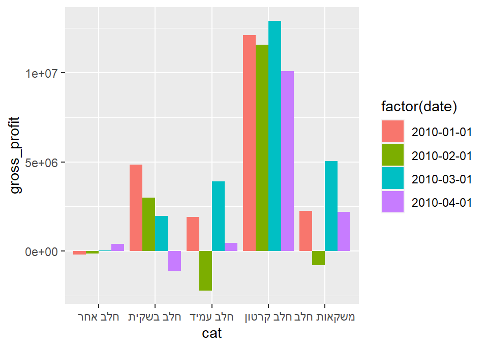

```r
ggplot(milk, aes(x = cat, y = gross_profit, fill = factor(date))) + geom_col(position = 'dodge')
```

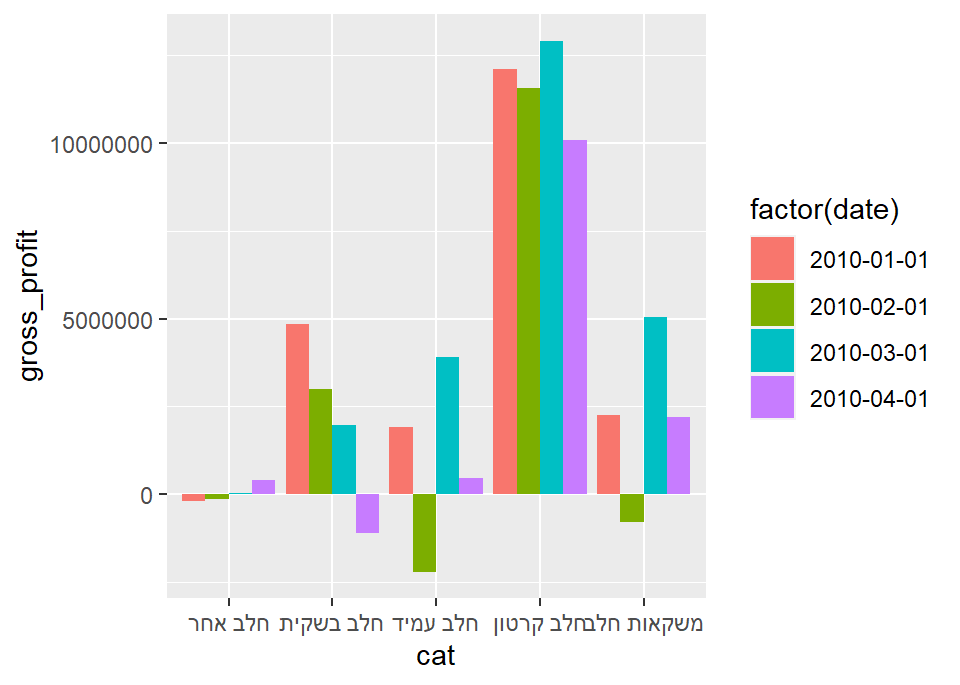

```r
# we can turn of scientific notation with:
options(scipen = 999)

ggplot(milk, aes(x = cat, y = gross_profit, fill = factor(date))) + geom_col(position = 'dodge')
```

אפשר לבנות את הגרף בחלקים ע"י שמירתו במשתנה

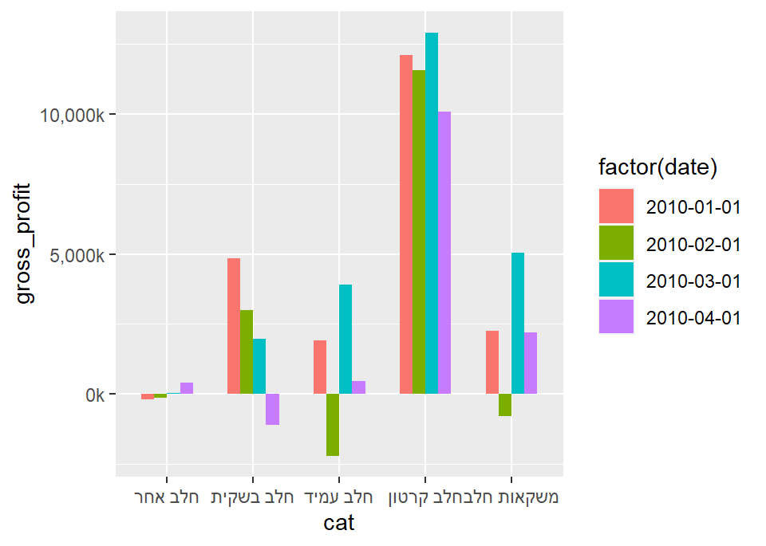

```r
plot1 <- ggplot(milk, aes(x = cat, y = gross_profit, fill = factor(date))) + geom_col(position = 'dodge', width = 0.6)

# Change the y axis look
plot1 <- plot1 +scale_y_continuous(labels = scales::label_number(scale = 1e-3, suffix = "k", big.mark = ","))

plot1
```

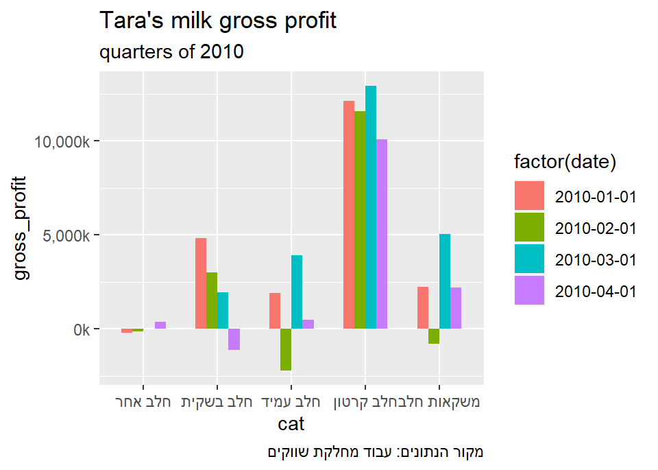

```r
# Add titles
plot1 + labs(title = "Tara's milk gross profit",
             subtitle = "quarters of 2010",
             caption = "מקור הנתונים: עבוד מחלקת שווקים")
```

## more data processing

כעת, נחשב את כל הרווח גולמי של הפירמה מכלל המוצרים עבור כל חודש, ונשווה את הרווחיות בין החודשים השונים. לשם כך נשתמש בפונקציות :  
`group_by` - המחלקת את בסיס הנתונים לתתי-בסיס נתונים.  
`summarize` - המסכמת ווקטור לסקלר באמצעות פונקציות סכימה.

```r
# for each small data set
gross <-
   tara %>%
   group_by(date) %>%
   summarize(monthly_gross_profit = sum(gross_profit))
## `summarise()` ungrouping output (override with `.groups` argument)

gross
```

```
## # A tibble: 4 x 2
##   date       monthly_gross_profit
##   <date>                    <dbl>
## 1 2010-01-01            92425079.
## 2 2010-02-01            98654309.
## 3 2010-03-01           122377914.
## 4 2010-04-01            80581380.
```

נחשב את שיעור התרומה לפדיון של כל חודש

```r
gross <-
  gross %>%
  mutate(percentage_gross_profit = monthly_gross_profit / sum(monthly_gross_profit) )

gross
```

```
## # A tibble: 4 x 3
##   date       monthly_gross_profit percentage_gross_profit
##   <date>                    <dbl>                   <dbl>
## 1 2010-01-01            92425079.                   0.235
## 2 2010-02-01            98654309.                   0.250
## 3 2010-03-01           122377914.                   0.311
## 4 2010-04-01            80581380.                   0.205
```

## plot

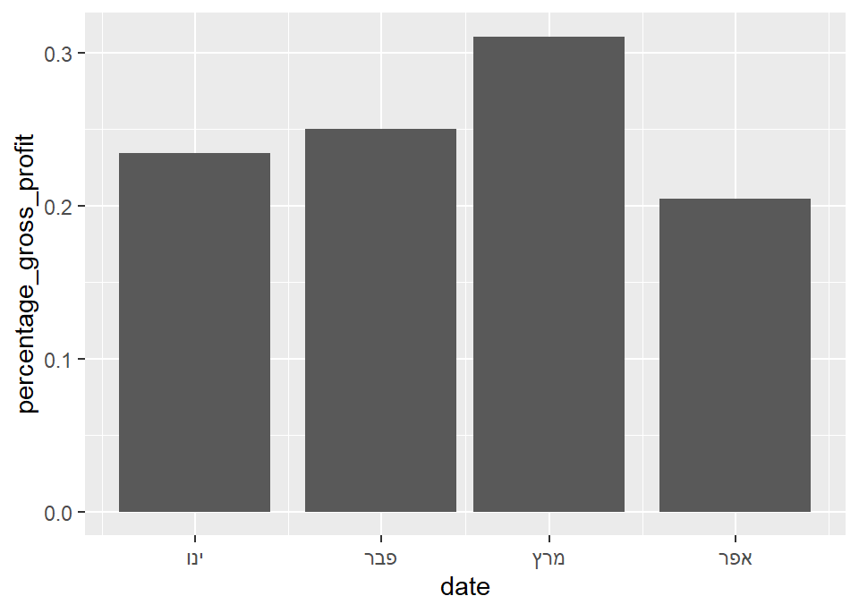

```r
ggplot(gross, aes(x = date, y = percentage_gross_profit)) + geom_col()
```

נייבא נתונים של פירמה נוספת - שטראוס - ונחשב נתחי שוק:

```r
list.files("1_data")
```

```
## [1] "Strauss.xlsx" "tara.RData"   "Tara.xlsx"    "Tnuva.xlsx"
```

```r
strauss <- readxl::read_xlsx(path = "1_data/Strauss.xlsx", sheet = "2010")

str(strauss)
## tibble [80 x 6] (S3: tbl_df/tbl/data.frame)
##  $ תאריך        : chr [1:80] "Q1Y2010" "Q1Y2010" "Q1Y2010" "Q1Y2010" ...
##  $ קטגוריה      : chr [1:80] "חלב קרטון" "חלב בשקית" "גבינות צהובות" "קוטג" ...
##  $ מכירה במשקל  : num [1:80] 27257695 31328874 1846696 4392111 4397204 ...
##  $ מכירות בשקלים: num [1:80] 111153144 100680429 70708532 64911992 62846280 ...
##  $ עלויות משתנות: num [1:80] 68806424 64216703 49671995 42312630 33380994 ...
##  $ עלויות קבועות: num [1:80] 33623168 33880792 15267249 22274699 17768689 ...

names(strauss) <- c("date", "cat", "q_k", "revenue", "vc", "fc")

# fix the date variable with parse_date
strauss$date <- parse_date(strauss$date, format = "%.%m%.%Y")
```

נחבר את הטבלאות עם הפונקציה `bind_rows`.

```r
dairy_data <- bind_rows(list(strauss = strauss, tara = tara), .id = "firm")

bind_rows(head(dairy_data, 3),tail(dairy_data, 3))
```

```
## # A tibble: 6 x 8
##   firm    date       cat              q_k   revenue      vc      fc gross_profit
##   <chr>   <date>     <chr>          <dbl>     <dbl>   <dbl>   <dbl>        <dbl>
## 1 strauss 2010-01-01 חלב קרטון     2.73e7    1.11e8  6.88e7  3.36e7          NA
## 2 strauss 2010-01-01 חלב בשקית     3.13e7    1.01e8  6.42e7  3.39e7          NA
## 3 strauss 2010-01-01 גבינות צהו~   1.85e6    7.07e7  4.97e7  1.53e7          NA
## 4 tara    2010-04-01 לאבנה         2.34e5    4.57e6  2.22e6  1.16e6     1196531.
## 5 tara    2010-04-01 משקאות יוג~   2.37e5    3.76e6  2.49e6  1.19e6       81250.
## 6 tara    2010-04-01 חלב אחר       1.07e5    3.04e6  2.02e6  6.30e5      393551.
```

```r
# its better to use View()
```

נחשב את הפדיון של כל פירמה בכל חודש ולאחר מכן נחשב את חלקו של הפדיון מסך הפדיון בענף

```r
# calculating the monthly revenue in each month for each firm:
ms_1 <- dairy_data %>%
  group_by(date, firm) %>%
  summarize(montly_revenue = sum(revenue))
## `summarise()` regrouping output by 'date' (override with `.groups` argument)

ms_1
```

```
## # A tibble: 8 x 3
## # Groups:   date [4]
##   date       firm    montly_revenue
##   <date>     <chr>            <dbl>
## 1 2010-01-01 strauss     823741154.
## 2 2010-01-01 tara        760527920.
## 3 2010-02-01 strauss     868702072.
## 4 2010-02-01 tara        807793014.
## 5 2010-03-01 strauss     868561427.
## 6 2010-03-01 tara        860599127.
## 7 2010-04-01 strauss     471981775.
## 8 2010-04-01 tara        877468464.
```

```r
# calculate proportion of revenue out of market revenue for each month
ms_2 <- ms_1 %>%
  group_by(date) %>%
  mutate( p = montly_revenue / sum(montly_revenue))

ms_2
```

```
## # A tibble: 8 x 4
## # Groups:   date [4]
##   date       firm    montly_revenue     p
##   <date>     <chr>            <dbl> <dbl>
## 1 2010-01-01 strauss     823741154. 0.520
## 2 2010-01-01 tara        760527920. 0.480
## 3 2010-02-01 strauss     868702072. 0.518
## 4 2010-02-01 tara        807793014. 0.482
## 5 2010-03-01 strauss     868561427. 0.502
## 6 2010-03-01 tara        860599127. 0.498
## 7 2010-04-01 strauss     471981775. 0.350
## 8 2010-04-01 tara        877468464. 0.650
```

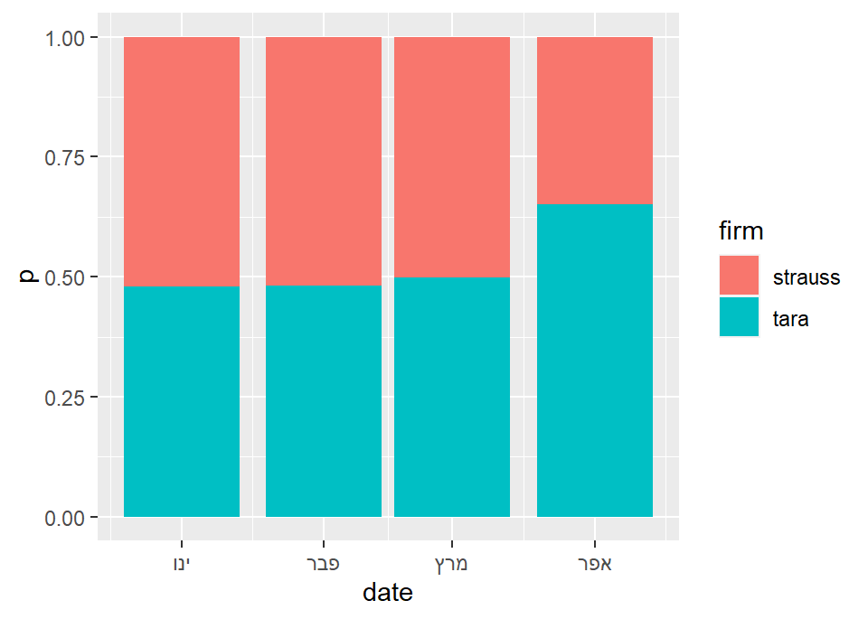

```r
plot2 <- ggplot(ms_2, aes(x = date, y = p, fill = firm)) +
  geom_col(position = 'stack')

plot2
```

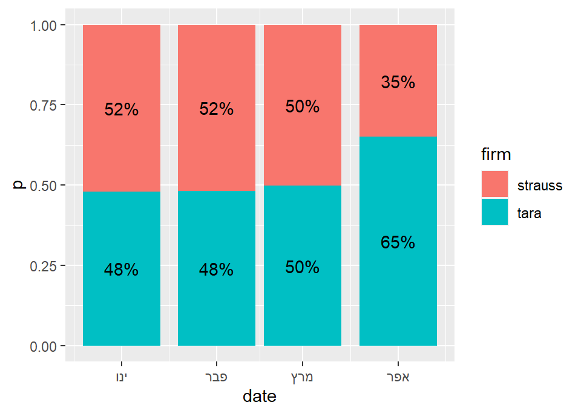

```r
plot2 + geom_text(aes(label = scales::label_percent(accuracy = 1)(p)),position = position_stack(vjust = 0.5))
```

## excercise

עכשיו תורכם.  
1. על סמך הקוד שהוצג, חברו את טבלאות שלושת הפירמות: טרה, שטראוס ותנובה וחשבו את נתחי השוק.  
2. חשבו את נתחי השוק בקטגורית החלב הניגר.